# Linear Regression Modeling

George Liu

December 30, 2018

```r
# Import the needed libraries
library(ggplot2)
library(GGally)
library(car)
# Read in the data
df1 <- read.csv('data1.csv', header=FALSE)
df2 <- read.csv('data2.csv', header=FALSE)
```

```r
# Rename columns
names(df1) <- c('x1', 'x2', 'x3', 'y')
names(df2) <- c('x1', 'x2', 'x3', 'y')
```

First, let’s check the correlation between variables

[figure not shown]

```r
ggpairs(df1)
```

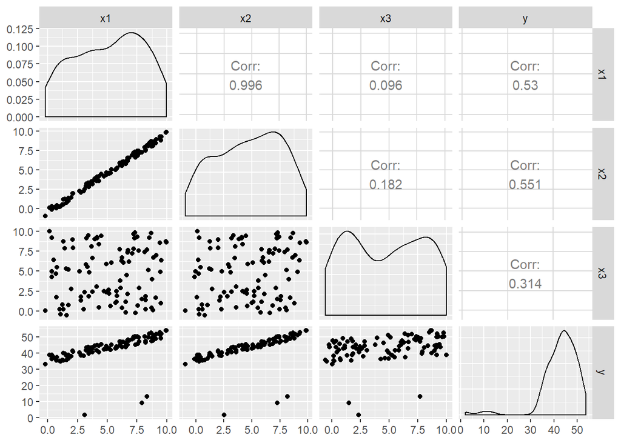

```r
ggpairs(df2)
```

For this dataset, x1 and x2 are close to be perfectly correlated, so chances are we only need one of them, not both.

Next, let’s confirm the above finding using variance inflation factor (VIF).

For df1:

```r
fit.all <- lm(y ~ ., data=df1)
vif(fit.all)
```

[output not shown]

For df2:

```r
#detach("package:usdm", unload=TRUE)
#library(car)
fit.all <- lm(y ~ ., data=df2)
#detach("package:usdm", unload=TRUE)
vif(fit.all)
```

```
##           x1           x2           x3
## 4.289622e+13 4.395634e+13 3.276172e+11
```

It does confirm our previous finding that x1 and x2 are correlated. Since x2 has a higher corrleatin with the target variable, we’ll remove x1 when building linear regression models.

Let’s now building the models. First for df1:

```r
fit.x1 <- lm(y ~ x1, data=df1)
fit.all <- lm(y ~ ., data=df1)
fit.step <- step(fit.all, direction = 'both', trace = 0)
anova(fit.x1, fit.all, fit.step)
```

```
## Analysis of Variance Table
##
## Model 1: y ~ x1
## Model 2: y ~ x1 + x2 + x3
## Model 3: y ~ x1 + x2
##   Res.Df    RSS Df Sum of Sq      F   Pr(>F)
## 1     98 4517.1
## 2     96 4076.9  2    440.20 5.1828 0.007287 **
## 3     97 4076.9 -1     -0.07 0.0016 0.968257
## ---
## Signif. codes:  0 '***' 0.001 '**' 0.01 '*' 0.05 '.' 0.1 ' ' 1
```

```r
summary(fit.x1)
```

```
##
## Call:
## lm(formula = y ~ x1, data = df1)
##
## Residuals:
##     Min      1Q  Median      3Q     Max
## -37.999  -0.631   0.980   2.810   4.222
##
## Coefficients:
##             Estimate Std. Error t value Pr(>|t|)
## (Intercept)  35.3302     1.4037  25.170  < 2e-16 ***
## x1            1.4782     0.2387   6.191  1.4e-08 ***
## ---
## Signif. codes:  0 '***' 0.001 '**' 0.01 '*' 0.05 '.' 0.1 ' ' 1
##
## Residual standard error: 6.789 on 98 degrees of freedom
## Multiple R-squared:  0.2812, Adjusted R-squared:  0.2738
## F-statistic: 38.33 on 1 and 98 DF,  p-value: 1.396e-08
```

```r
summary(fit.step)
```

```
##
## Call:
## lm(formula = y ~ x1 + x2, data = df1)
##
## Residuals:
##     Min      1Q  Median      3Q     Max
## -36.620   0.603   1.113   1.577   2.373
##
## Coefficients:
##             Estimate Std. Error t value Pr(>|t|)
## (Intercept)   39.042      1.764  22.130  < 2e-16 ***
## x1            -7.024      2.637  -2.663  0.00906 **
## x2             8.431      2.605   3.236  0.00166 **
## ---
## Signif. codes:  0 '***' 0.001 '**' 0.01 '*' 0.05 '.' 0.1 ' ' 1
##
## Residual standard error: 6.483 on 97 degrees of freedom
## Multiple R-squared:  0.3512, Adjusted R-squared:  0.3378
## F-statistic: 26.26 on 2 and 97 DF,  p-value: 7.706e-10
```

Now for df2:

```r
fit.x1 <- lm(y ~ x1 + x3, data=df2)
fit.x2 <- lm(y ~ x2 + x3, data=df2)
fit.all <- lm(y ~ ., data=df2)
fit.step <- step(fit.all, direction = 'both', trace = 0)
anova(fit.x1, fit.x2, fit.all, fit.step)
```

```
## Analysis of Variance Table
##
## Model 1: y ~ x1 + x3
## Model 2: y ~ x2 + x3
## Model 3: y ~ x1 + x2 + x3
## Model 4: y ~ x1 + x2
##   Res.Df    RSS Df Sum of Sq      F Pr(>F)
## 1     97 4076.9
## 2     97 4076.9  0  0.000003
## 3     96 4076.9  1  0.067620 0.0016 0.9683
## 4     97 4076.9 -1 -0.067604 0.0016 0.9683
```

This is interesting. On one hand, it does show that the models based on x1 and x2 are not significantly different; on the other hand, it seems all models are quite similar. Let’s build individual models without the x1 variable:

```r
fit.x2 <- lm(y ~ x2, data=df2)
fit.all <- lm(y ~ x2 + x3, data=df2)
fit.step <- step(fit.all, direction = 'both', trace = 0)
anova(fit.x2, fit.all, fit.step)
```

```
## Analysis of Variance Table
##
## Model 1: y ~ x2
## Model 2: y ~ x2 + x3
## Model 3: y ~ x2 + x3
##   Res.Df    RSS Df Sum of Sq      F   Pr(>F)
## 1     98 4375.1
## 2     97 4076.9  1    298.15 7.0937 0.009058 **
## 3     97 4076.9  0      0.00
## ---
## Signif. codes:  0 '***' 0.001 '**' 0.01 '*' 0.05 '.' 0.1 ' ' 1
```

Great! It’s indeed because of the multicollinearity that leads to some confusion. So x3 variable does offer value here. Now let’s check using adjusted R squared value.

```r
summary(fit.x2)
```

```
##
## Call:
## lm(formula = y ~ x2, data = df2)
##
## Residuals:
##     Min      1Q  Median      3Q     Max
## -37.642  -0.257   1.052   2.440   3.504
##
## Coefficients:
##             Estimate Std. Error t value Pr(>|t|)
## (Intercept)  35.7284     1.2890  27.717  < 2e-16 ***
## x2            1.5178     0.2321   6.539 2.81e-09 ***
## ---
## Signif. codes:  0 '***' 0.001 '**' 0.01 '*' 0.05 '.' 0.1 ' ' 1
##
## Residual standard error: 6.682 on 98 degrees of freedom
## Multiple R-squared:  0.3038, Adjusted R-squared:  0.2967
## F-statistic: 42.76 on 1 and 98 DF,  p-value: 2.814e-09
```

```r
summary(fit.step)
```

```
##
## Call:
## lm(formula = y ~ x2 + x3, data = df2)
##
## Residuals:
##     Min      1Q  Median      3Q     Max
## -36.620   0.603   1.113   1.577   2.373
##
## Coefficients:
##             Estimate Std. Error t value Pr(>|t|)
## (Intercept)  33.7411     1.4564  23.167  < 2e-16 ***
## x2            1.4070     0.2290   6.143 1.79e-08 ***
## x3            0.5301     0.1990   2.663  0.00906 **
## ---
## Signif. codes:  0 '***' 0.001 '**' 0.01 '*' 0.05 '.' 0.1 ' ' 1
##
## Residual standard error: 6.483 on 97 degrees of freedom
## Multiple R-squared:  0.3512, Adjusted R-squared:  0.3378
## F-statistic: 26.26 on 2 and 97 DF,  p-value: 7.706e-10
```

**Again, it confirms that the best model uses both x2 and x3 as predictor variables. Also, the model is significant based on the p-value.**

**Reference**

- [How to test and avoid multicollinearity in mixed linear model?](https://stats.stackexchange.com/questions/82984/how-to-test-and-avoid-multicollinearity-in-mixed-linear-model)
- [unable to find an inherited method for function ‘vif’ for signature ‘“integer”’](https://stackoverflow.com/questions/32158177/unable-to-find-an-inherited-method-for-function-vif-for-signature-integer)